# Worksheet 5

Thomas Fuß

WS2425

## DOM from Berlin´s surface waters

Data source: Romero Gonzalez-Quijano 2022. Biogeosciences 19: 2841-2853, https://doi.org/10.5194/bg-19-2841-2022 A range of urban water bodies in Berlin´s extensive ‘aquascape’ were investigated for properties of dissolved organic matter (DOM). There were 4 seasonal campaigns, water bodies were classified into 2 lotic (rivers and streams) and 2 lentic (lakes and ponds) types. DOM can be considered to drive and indicate various ecosystem functions like respiration, primary production. It may also indicate pollution and react to input from the terrestrial surrounding.

We will need the ‘vegan’ package (a lot of ordinations coded by ecologists for ecologists). Some more classical ordinations like PCA are available in the package ‘MASS’.

```r
library(vegan)
```

```r
library(MASS)
library(shape) # just for better arrows drawing
```

```r
DOM<-read.table(file="data/DOM_Berlin_Romero.txt",header=TRUE)
names(DOM)
```

```
##  [1] "sampleID"   "Season"     "Site"       "Date"       "Type"
##  [6] "latitude"   "longitude"  "SR"         "E2_E3"      "E4_E6"
## [11] "SUVA254"    "FI"         "HIX"        "fresh"      "DOC"
## [16] "C1"         "C2"         "C3"         "C4"         "C5"
## [21] "C6"         "C7"         "HMWS.C"     "humic.C"    "LMWS.C"
## [26] "HMWS.N"     "humic.N"    "avgmolmass" "molrich"    "DBE"
## [31] "AI"         "MLB"        "H_C"        "O_C"        "NH4"
## [36] "NO3"        "TP"         "Chla"       "AGR"        "FOR"
## [41] "PAV"        "URG"
```

The dataset includes DOC indicating pure quantity and several descriptors of DOM quality measured by optical instruments (SR:fresh,C1:C6), chromatography (HMWS.C:humic.N) and mass spectrometry (avgmolmass:O_C). See the Excel sheet or the original paper for detailed variable description. Mass-spectrometric information only exist for three seasons. The dataset also includes variables that should be considered as drivers of DOM composition: nutrient concentrations, Chlorophyll-a, landuse percentages (NH4:URG).

1. DOM consists of thousands of chemical structures. We try to understand its ‘composition’ by throwing analytics on it to produce many descriptors, which are likely at least partially collinear. Reduce the dimensionality of the DOM dataset to a meaningful number of dimensions by PCA. Leave away incomplete mass-spectrometric information. How much variance do individual PC-axes explain? How many axes do you need to properly represent the dataset? Note that the latter question may be answered based on PCA-results or based on theoretical considerations considering the study design of 4 water body types sampled across 4 seasons.

```r
DOM2<-DOM[,8:27] # only these variables have complete info for all seasons
any(is.na(DOM[,8:27]))
```

```
## [1] FALSE
```

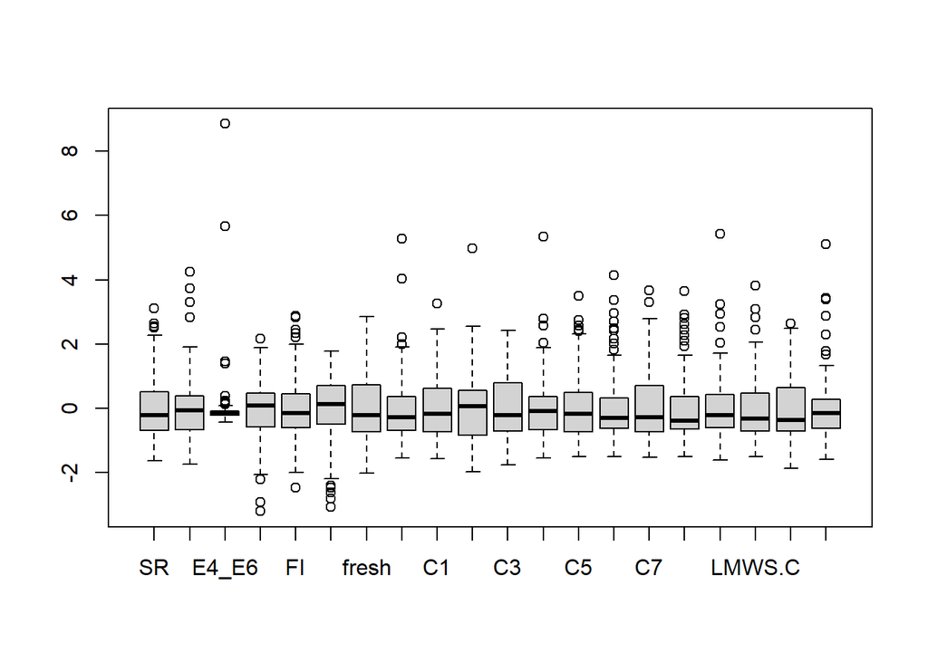

```r
boxplot(scale(DOM2))
```

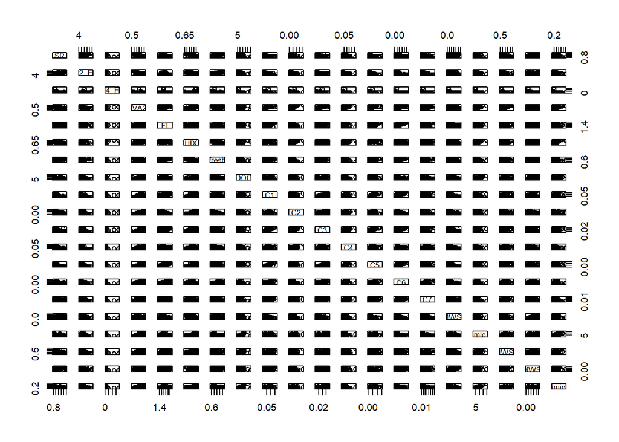

```r
# also make histograms
# maybe consider transformation of variables to improve linearity of relationships
plot(DOM2)
```

```r
# use quartz() or x11() to open a separate graphical device if you need it

# # variable E4_E6 behaves differently than others (highly skewed)
any(DOM2$E4_E6<=0)
```

```
## [1] FALSE
```

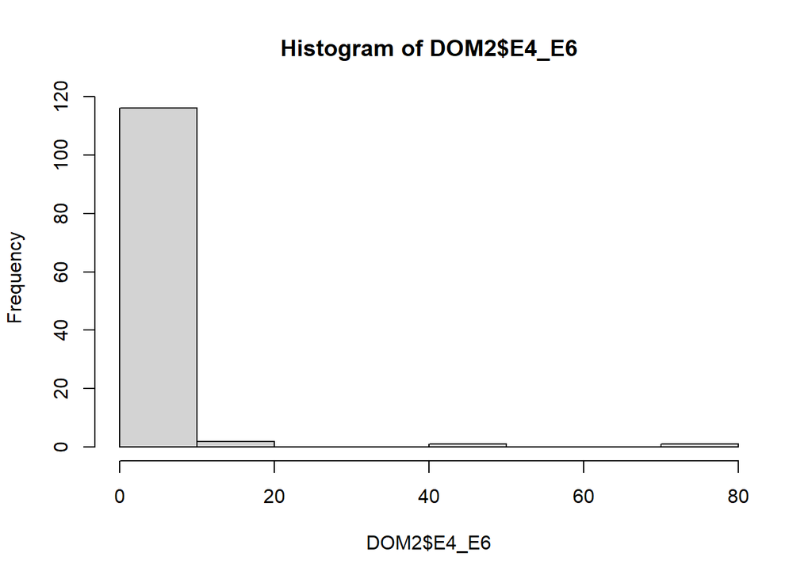

```r
hist(DOM2$E4_E6)
```

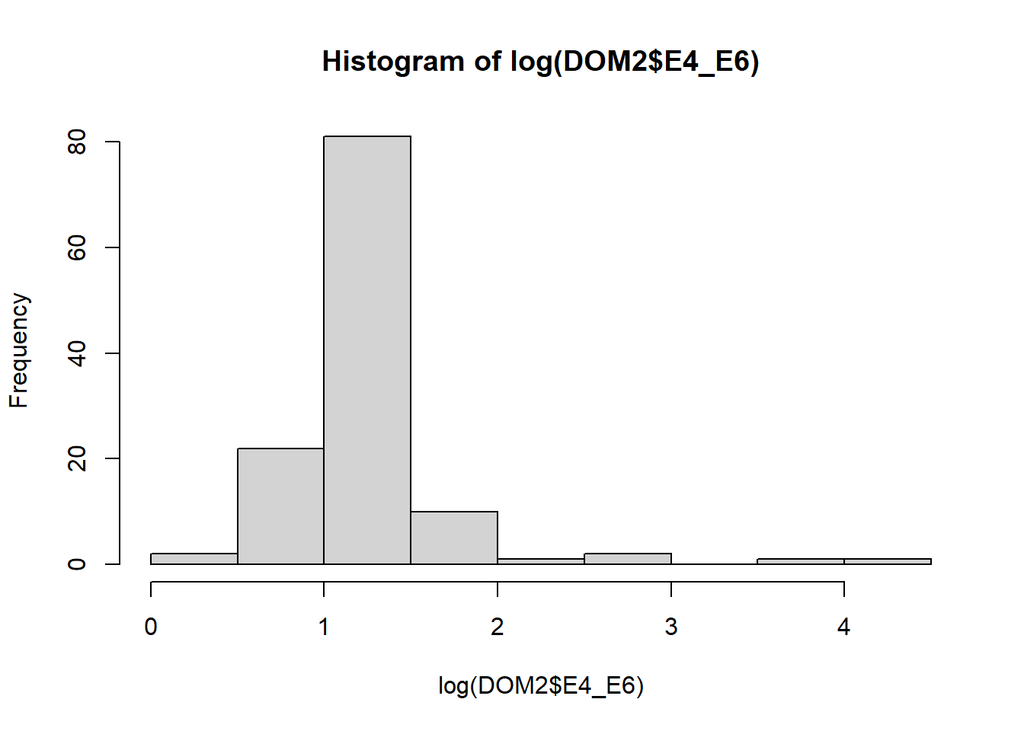

```r
hist(log(DOM2$E4_E6))
```

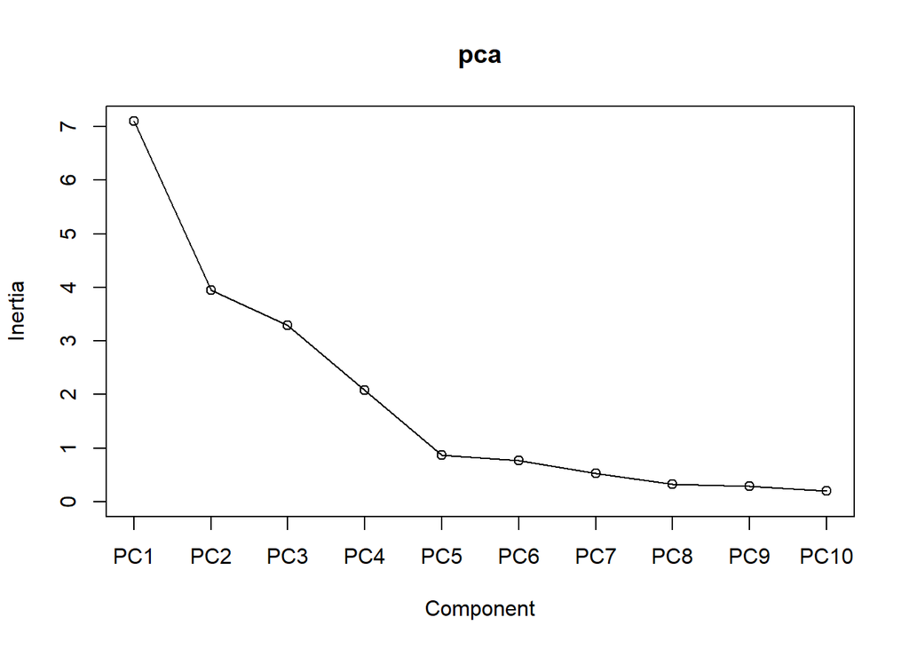

```r
DOM2$E4_E6<-log(DOM2$E4_E6)

# run PCA
#with package vegan
pca<-rda(DOM2, scale=TRUE)
# alternatively use prcromp from pca<-prcomp(DOM2, center=TRUE, scale.=TRUE)

#summary(pca)
#eigenvals(pca)
screeplot(pca,type="lines")
```

```r
# We keep 2 axes of the PCA for graphing and further analysis. Alternatively we could keep 4, which is supported by the Scree plot as well and also by the eigenvalues (these drop below 1 at PC5)
```

2. Create a biplot for PC1 and PC2 with the most important variables defining these two axes. Plot the various water bodies and code symbol shape and symbol color to represent the study design targeting 4 water body types and 4 seasons. Note that sites and variables (or subsets thereof) do not have to be plotted onto a single biplot.

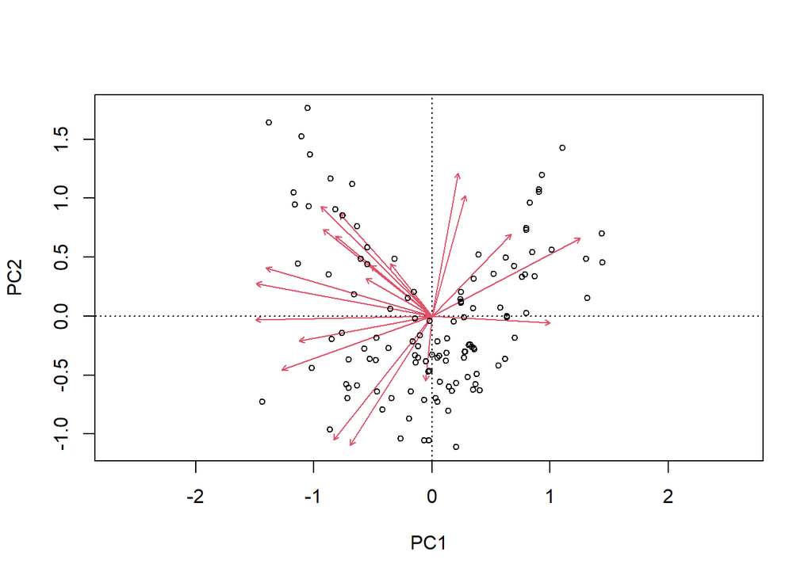

```r
# correlation biplot
biplot(pca) # quick and dirty
```

```r
# plot by hand:
# use different colors for water body types
#str(DOM)
DOM$col.type<-as.factor(DOM$Type)
levels(DOM$col.type)
```

```
## [1] "lake"   "pond"   "river"  "stream"
```

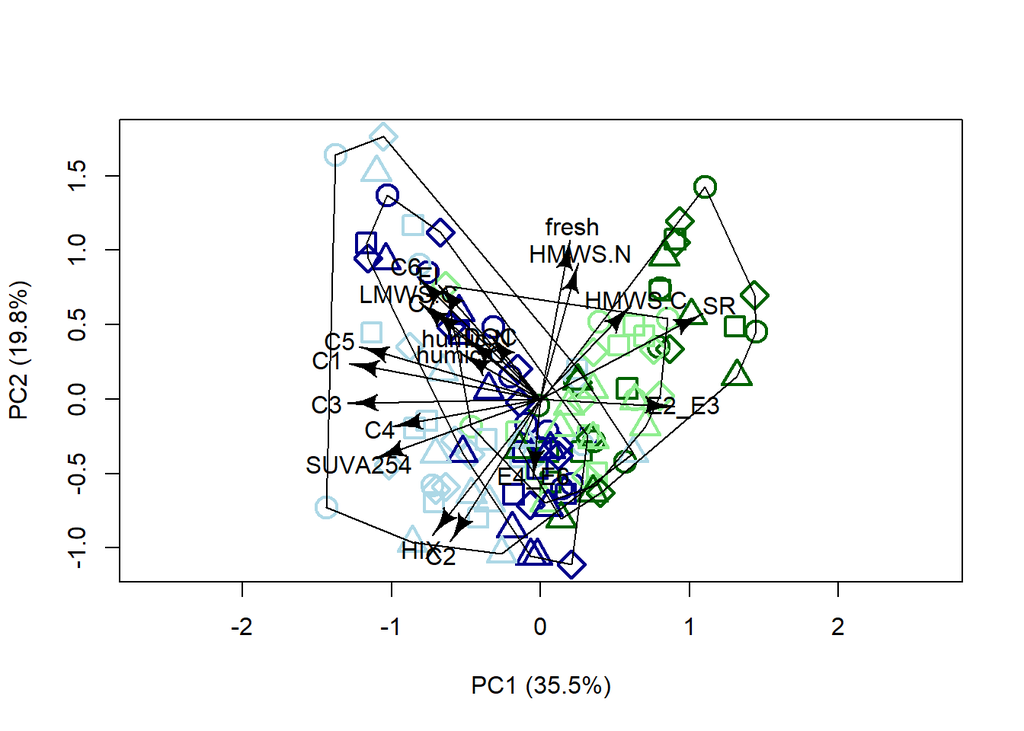

```r
levels(DOM$col.type)<-c("darkgreen","lightgreen","darkblue","lightblue")
DOM$col.type<-as.character(DOM$col.type)

# could use different symbols for season
DOM$pch.season<-as.factor(DOM$Season)
levels(DOM$pch.season)<-c(21:24)
DOM$pch.season<-as.numeric(as.character(DOM$pch.season))

site_scores<-scores(pca, display="sites")
loadings<-scores(pca, display="species")

#select only most important variables for plotting
pc1_loads<-sort(abs (loadings[,1]), decreasing = TRUE)
pc2_loads<-sort(abs (loadings[,2]), decreasing = TRUE)
sel.loads.names<-c(names(pc1_loads)[1:5], names(pc2_loads)[1:5])
sel.loads<-loadings[sel.loads.names,]
#you could now use "sel.loads" instead of "loadings" in the plot

#biplot
#summary(pca)
plot(site_scores, asp=1, pch=DOM$pch.season, col=DOM$col.type,cex=2,lwd=2,
     xlab="PC1 (35.5%)", ylab="PC2 (19.8%)")
arrows<-loadings*0.8 # with reduction factor
arrows.text<-arrows*1.2 # position of text
Arrows(x0=0,y0=0,x1=arrows[,1],y1=arrows[,2])
text(x=arrows.text[,1], y=arrows.text[,2], labels=rownames(loadings))

#belongs to task 3
ordihull(pca, groups=DOM$Type) #could link groups together, however, for this particular graph it seems too much
```

3. Assess differences between water body types with respect to average composition of DOM and with respect to seasonal turnover of DOM composition. This question can be translated to an assessment of location and of seasonal variation along PC1 and PC2. You may add univariate formal hypothesis tests (Anova, t-test, Bartlett-test, F-test) using the PCs as response metavariables. Use various graphical means for plotting of the site scores for illustration. Which water bodies differ markedly among each other in DOM? Which water bodies show more seasonal DOM turnover?

```r
# run 2-way ANOVA assuming complete independence between all cases and seasons (120 different water bodies...)
m<-lm(site_scores[,1]~Season*Type,data=DOM)
anova(m)
```

```
## Analysis of Variance Table
##
## Response: site_scores[, 1]
##              Df Sum Sq Mean Sq F value Pr(>F)
## Season        3  0.078  0.0260  0.1260 0.9446
## Type          3 26.691  8.8971 43.1055 <2e-16 ***
## Season:Type   9  0.550  0.0611  0.2961 0.9744
## Residuals   104 21.466  0.2064
## ---
## Signif. codes:  0 '***' 0.001 '**' 0.01 '*' 0.05 '.' 0.1 ' ' 1
```

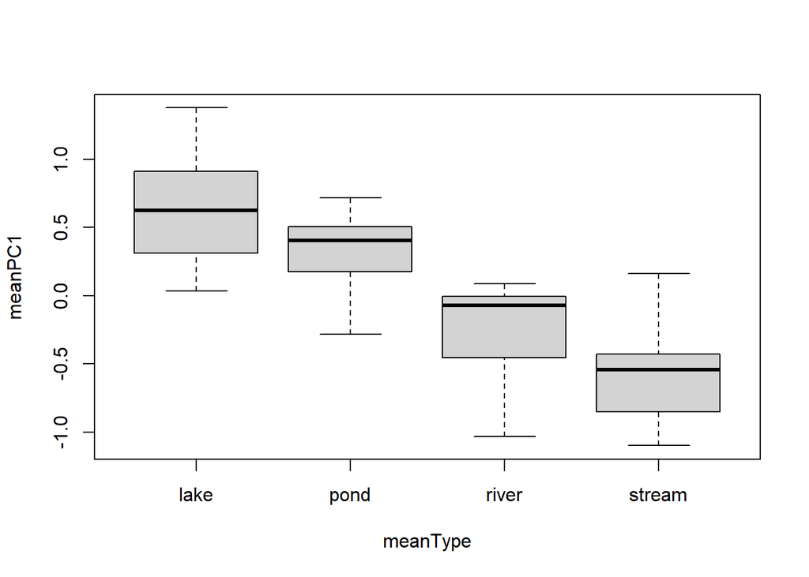

```r
# could do Bartlett-test, etc...
# a bit sloppy because it ignores repeated measures for each site, thus wrong
# could include "site" as random factor in a mixed model (but we don´t know how this works)
# or compute average per site over 4 seasons, information loss, but correct test
meanPC1<-tapply(site_scores[,1],DOM$Site, mean) # site-specific average location on PC1
varPC1<-tapply(site_scores[,1], DOM$Site, var) # site-specific seasonal variance on PC1
meanType<-DOM$Type[match(names(meanPC1), DOM$Site)]

boxplot(meanPC1~meanType)
```

```r
bartlett.test(meanPC1~meanType) #test for variance homogeneity to meet ANOVA prerequisite
```

```
##
##  Bartlett test of homogeneity of variances
##
## data:  meanPC1 by meanType
## Bartlett's K-squared = 0.61323, df = 3, p-value = 0.8934
```

```r
m2<-lm(meanPC1~meanType)
anova(m2)
```

```
## Analysis of Variance Table
##
## Response: meanPC1
##           Df Sum Sq Mean Sq F value    Pr(>F)
## meanType   3 7.2491 2.41637  15.442 4.045e-06 ***
## Residuals 28 4.3813 0.15648
## ---
## Signif. codes:  0 '***' 0.001 '**' 0.01 '*' 0.05 '.' 0.1 ' ' 1
```

```r
TukeyHSD(aov(m2))
```

```
##   Tukey multiple comparisons of means
##     95% family-wise confidence level
##
## Fit: aov(formula = m2)
##
## $meanType
##                    diff        lwr         upr     p adj
## pond-lake    -0.3247500 -0.9020516  0.25255165 0.4304481
## river-lake   -0.8988525 -1.4431376 -0.35456730 0.0005827
## stream-lake  -1.2278821 -1.7721673 -0.68359692 0.0000069
## river-pond   -0.5741025 -1.1183877 -0.02981734 0.0357827
## stream-pond  -0.9031321 -1.4474173 -0.35884696 0.0005502
## stream-river -0.3290296 -0.8381618  0.18010254 0.3110861
```

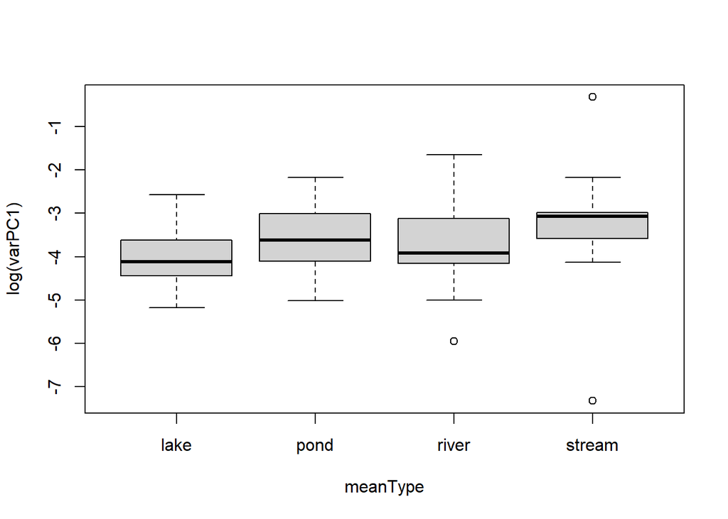

```r
# there is a significant effect of water body type on mean location along PC1

boxplot(log(varPC1)~meanType)
```

```r
bartlett.test(log(varPC1)~meanType)
```

```
##
##  Bartlett test of homogeneity of variances
##
## data:  log(varPC1) by meanType
## Bartlett's K-squared = 4.9504, df = 3, p-value = 0.1755
```

```r
m3<-lm(log(varPC1)~meanType)
anova(m3)
```

```
## Analysis of Variance Table
##
## Response: log(varPC1)
##           Df Sum Sq Mean Sq F value Pr(>F)
## meanType   3  1.978 0.65941  0.3696 0.7755
## Residuals 28 49.959 1.78424
```

```r
# there is NO significant effect of water body type on seasonal variance along PC1
```

4. Adding incomplete descriptors: Mass-spectrometric information is incomplete (we lack data from one season). It could still be informative to show how these data behave in the ordination space. Compute correlations with PCs and plot these as (maybe differently colored) arrows into ordination space.

```r
#not done
```

5. Assess potential drivers: The dataset includes a few variables that could be considered drivers of DOM composition (or drivers of processes that influence DOM). Assess these drivers by plotting them into ordination space and running correlations/regressions with PC1 and PC2.

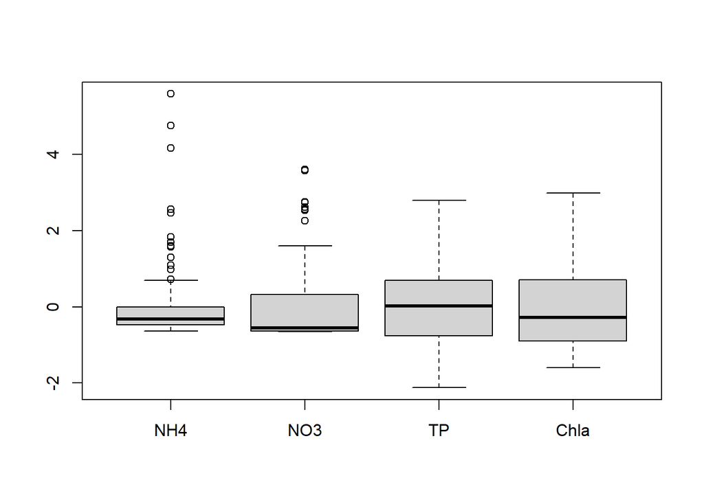

```r
# Extract drivers
DOM4<-DOM[,35:38]
#apply(DOM4, 2, hist)
DOM4<-log1p(DOM4) #log1p because of zeros
boxplot(scale(DOM4))
```

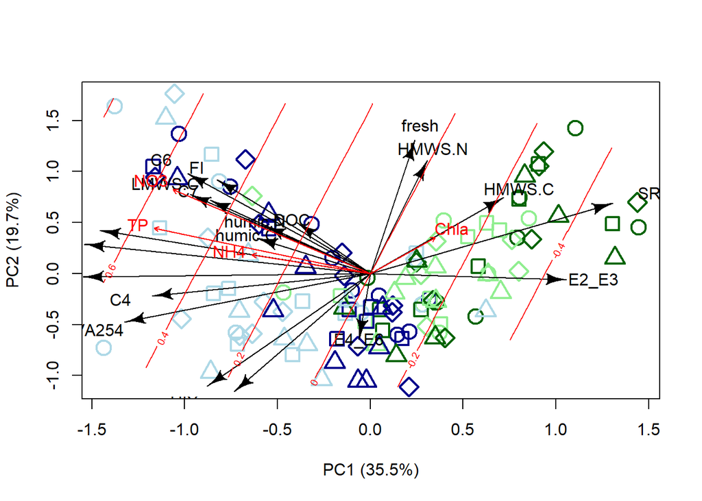

```
##
## Family: gaussian
## Link function: identity
##
## Formula:
## y ~ s(x1, x2, k = 10, bs = "tp", fx = FALSE)
##
## Estimated degrees of freedom:
## 1.72  total = 2.72
##
## REML score: 167.3838
```

```r
DOM4<-scale(DOM4)

# first just rebuild plot from above
plot(site_scores, pch=DOM$pch.season,col=DOM$col.type,cex=2,lwd=2,
     xlab="PC1 (35.5%)", ylab="PC2 (19.7%)")
arrows<-loadings # with reduction factor
arrows.text<-arrows*1.2 # position of text
Arrows(x0=0,y0=0,x1=arrows[,1],y1=arrows[,2])
text(x=arrows.text[,1], y=arrows.text[,2], labels=rownames(loadings))


## and use envfit to fit drivers onto the ordination
# The function envfit calculates multiple regression of environmental variable with ordination axes (environmental variable is used as dependent and selected ordination axes as explanatory variables). Significance is tested by permutation test. Vectors (for continual variables) and centroids (for categorical variables) can be projected onto ordination diagram using plot function.
fit<-envfit(pca, DOM4)
plot(fit, col = "red")

#Alternatively, one could add drivers as a surface plotted in the ordination
ordisurf(pca, DOM4[,1], add=TRUE) #here done only for one driver
```

```r
# consider regressions to explain DOM quality
m1<-lm(site_scores[,1]~., data=data.frame(DOM4))
summary(m1)
```

```
##
## Call:
## lm(formula = site_scores[, 1] ~ ., data = data.frame(DOM4))
##
## Residuals:
##      Min       1Q   Median       3Q      Max
## -1.37157 -0.30725  0.02631  0.28716  1.06627
##
## Coefficients:
##               Estimate Std. Error t value Pr(>|t|)
## (Intercept) -6.284e-19  4.234e-02   0.000  1.00000
## NH4         -1.108e-01  4.694e-02  -2.361  0.01991 *
## NO3         -2.032e-01  5.073e-02  -4.005  0.00011 ***
## TP          -2.663e-01  5.401e-02  -4.932 2.77e-06 ***
## Chla         1.131e-01  4.647e-02   2.435  0.01643 *
## ---
## Signif. codes:  0 '***' 0.001 '**' 0.01 '*' 0.05 '.' 0.1 ' ' 1
##
## Residual standard error: 0.4638 on 115 degrees of freedom
## Multiple R-squared:  0.493,  Adjusted R-squared:  0.4754
## F-statistic: 27.96 on 4 and 115 DF,  p-value: 3.201e-16
```

6. Assessing drivers of DOM composition by post-hoc analysis of an unconstrained ordination like a PCA may not work well if those drivers exert only weak control or if important drivers were missed. Then the (variance-driven) PCA-dimensions may not be well aligned with the available drivers. RDA looks explicitly for an ordination that can be well aligned with a matrix of constraining variables. Run a RDA and compare its outcomes to PCA. As drivers of DOM composition you can consider nutrient concentrations, Chlorophyll-a, landuse percentages (NH4:URG). What do you learn when PCA and RDA result in either similar or different ordinations?

```r
# do this much better with a RDA
zDOM2<-scale(DOM2) # must at least be centered even if dimensionally homogeneous!
xmat<-data.frame(DOM4) # the constraints (or drivers or predictors)
myrda<-rda(zDOM2~.,data=xmat) # take care: confusing X and Y argument names if you work without formula notation

R2.obs <- RsquareAdj(myrda)$r.squared #observed variance explained


#Permutation test to test significance of our result:
xmat.rand <- xmat[sample(1:nrow(xmat)),]  # the function "sample" will reshuffle the rows with constraints
myrda.rand<-rda(zDOM2~.,data=xmat.rand) #
RsquareAdj(myrda.rand)$r.squared
```

```
## [1] 0.04017627
```

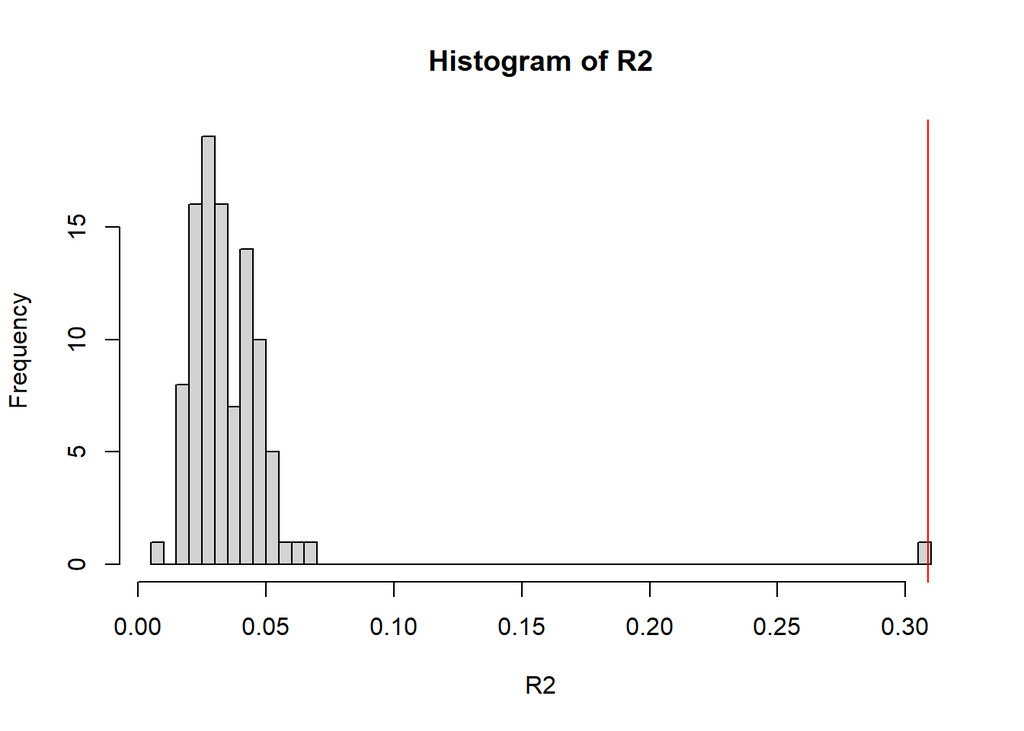

```r
#put this in loop and do it n.perm times
n.perm <- 99  # set the number of permutations
R2.rand <- rep(NA,n.perm)
for(i in 1:n.perm){
        xmat.rand <- xmat[sample(1:nrow(xmat)),]
        myrda.rand<-rda(zDOM2~.,data=xmat.rand) #
        R2.rand[i]<-RsquareAdj(myrda.rand)$r.squared
}

# The vector R2.rand contains 99 values of variance explained by random variables.
R2 <- c (R2.rand, R2.obs)
hist (R2, nclass = length(R2))  #argument "nclass" separates the bars into n.perm categories
abline (v = R2.obs, col = 'red')  # red line to indicate where in the histogram is the observed value
```

```r
# To calculate the significance, we need to know what is the number of cases in which the variance explained by random explanatory variables was higher or equal to the observed one (explained by real variables).
P <- sum (R2 >= R2.obs)/(n.perm + 1)  # 0.01
#The resulting P-value is 0.01, which is the lowest P-value we can get with the Monte Carlo permutation test based on 99 permutations.

# the test of the significance for constrained ordination is done by function anova (this may be a bit confusing name, since it is not really calculating ANOVA)
anova(myrda,by="axis",model="direct",perm.max=9999,step=1000)
```

```
## Permutation test for rda under direct model
## Forward tests for axes
## Permutation: free
## Number of permutations: 999
##
## Model: rda(formula = zDOM2 ~ NH4 + NO3 + TP + Chla, data = xmat)
##           Df Variance       F Pr(>F)
## RDA1       1   3.9356 32.7430  0.001 ***
## RDA2       1   1.2040 10.0172  0.001 ***
## RDA3       1   0.6201  5.1590  0.005 **
## RDA4       1   0.4176  3.4743  0.009 **
## Residual 115  13.8226
## ---
## Signif. codes:  0 '***' 0.001 '**' 0.01 '*' 0.05 '.' 0.1 ' ' 1
```

```r
anova(myrda,by="term",model="direct",perm.max=9999,step=1000)
```

```
## Permutation test for rda under direct model
## Terms added sequentially (first to last)
## Permutation: free
## Number of permutations: 999
##
## Model: rda(formula = zDOM2 ~ NH4 + NO3 + TP + Chla, data = xmat)
##           Df Variance       F Pr(>F)
## NH4        1   1.1306  9.4060  0.001 ***
## NO3        1   2.9540 24.5760  0.001 ***
## TP         1   1.2962 10.7843  0.001 ***
## Chla       1   0.7966  6.6273  0.001 ***
## Residual 115  13.8226
## ---
## Signif. codes:  0 '***' 0.001 '**' 0.01 '*' 0.05 '.' 0.1 ' ' 1
```

```r
anova(myrda,by="margin",model="direct",perm.max=9999,step=1000) #testing the variance explained by each explanatory variable with all the others used as covariables (independently from their order in the model)
```

```
## Permutation test for rda under direct model
## Marginal effects of terms
## Permutation: free
## Number of permutations: 999
##
## Model: rda(formula = zDOM2 ~ NH4 + NO3 + TP + Chla, data = xmat)
##           Df Variance       F Pr(>F)
## NH4        1   0.6669  5.5485  0.003 **
## NO3        1   1.6045 13.3486  0.001 ***
## TP         1   1.1780  9.8009  0.001 ***
## Chla       1   0.7966  6.6273  0.001 ***
## Residual 115  13.8226
## ---
## Signif. codes:  0 '***' 0.001 '**' 0.01 '*' 0.05 '.' 0.1 ' ' 1
```

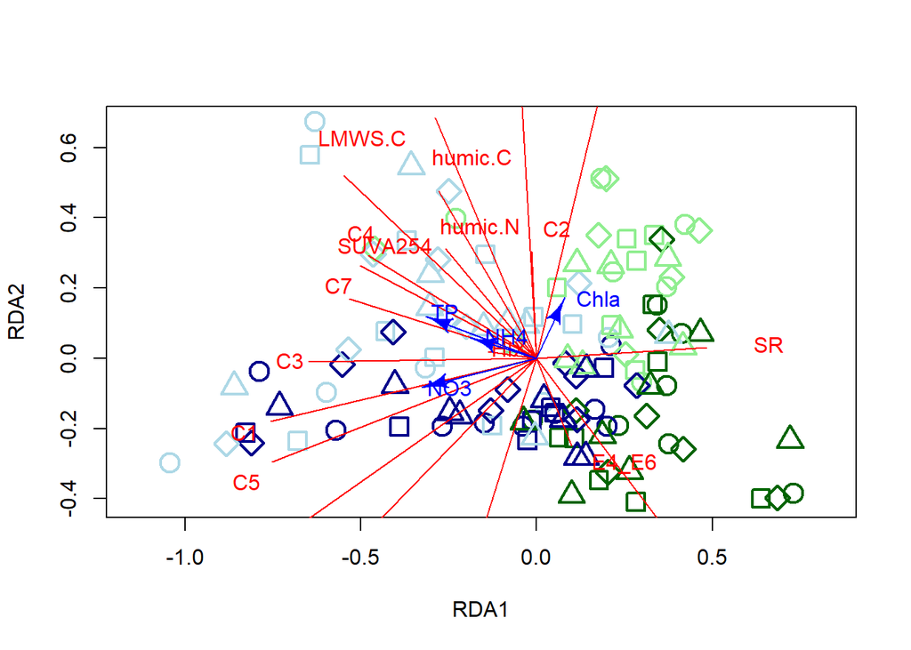

```r
sites<-scores(myrda,choices=c(1,2),display="sites",scaling=1)
lcs<-scores(myrda,choices=c(1,2),display="lc",scaling=1)
species<-scores(myrda,choices=c(1,2),display="species",scaling=1)
constraints<-scores(myrda,choices=c(1,2),display="bp",scaling=1)

plot(sites,asp=1,pch=DOM$pch.season,col=DOM$col.type,cex=2,lwd=2)

arrows.spec<-species*0.3 # with reduction/extension factor
arrows.spec.text<-arrows.spec*1.2 # position of text
Arrows(x0=0,y0=0,x1=arrows.spec[,1],y1=arrows.spec[,2],lwd=1,arr.length=0,col="red")
text(arrows.spec.text[,1:2],label=rownames(species),pos=4,cex=1,col="red")

arrows.const<-constraints*0.8 # with reduction/extension factor
arrows.const.text<-arrows.const*1.2
Arrows(x0=0,y0=0,x1=arrows.const[,1],y1=arrows.const[,2],lwd=1,col="blue")
text(arrows.const.text,label=rownames(constraints),pos=4,cex=1,col="blue")
```